# Loan Data

> The dataset in hand contains the relevant information of 113,937 loans isseued between 2005 and 2014.

# Wrangling

```python
import numpy as np
import pandas as pd
import matplotlib.pyplot as plt
import seaborn as sns

%matplotlib inline
```

```python
df = pd.read_csv('prosperLoanData.csv')
```

```python
df.head()
```

|  | ListingKey | ListingNumber | ListingCreationDate | CreditGrade | Term | LoanStatus | ClosedDate | BorrowerAPR | BorrowerRate | LenderYield | ... | LP_ServiceFees | LP_CollectionFees | LP_GrossPrincipalLoss | LP_NetPrincipalLoss | LP_NonPrincipalRecoverypayments | PercentFunded | Recommendations | InvestmentFromFriendsCount | InvestmentFromFriendsAmount | Investors |
| --- | --- | --- | --- | --- | --- | --- | --- | --- | --- | --- | --- | --- | --- | --- | --- | --- | --- | --- | --- | --- | --- |
| 0 | 1021339766868145413AB3B | 193129 | 2007-08-26 19:09:29.263000000 | C | 36 | Completed | 2009-08-14 00:00:00 | 0.16516 | 0.1580 | 0.1380 | ... | -133.18 | 0.0 | 0.0 | 0.0 | 0.0 | 1.0 | 0 | 0 | 0.0 | 258 |
| 1 | 10273602499503308B223C1 | 1209647 | 2014-02-27 08:28:07.900000000 | NaN | 36 | Current | NaN | 0.12016 | 0.0920 | 0.0820 | ... | 0.00 | 0.0 | 0.0 | 0.0 | 0.0 | 1.0 | 0 | 0 | 0.0 | 1 |
| 2 | 0EE9337825851032864889A | 81716 | 2007-01-05 15:00:47.090000000 | HR | 36 | Completed | 2009-12-17 00:00:00 | 0.28269 | 0.2750 | 0.2400 | ... | -24.20 | 0.0 | 0.0 | 0.0 | 0.0 | 1.0 | 0 | 0 | 0.0 | 41 |
| 3 | 0EF5356002482715299901A | 658116 | 2012-10-22 11:02:35.010000000 | NaN | 36 | Current | NaN | 0.12528 | 0.0974 | 0.0874 | ... | -108.01 | 0.0 | 0.0 | 0.0 | 0.0 | 1.0 | 0 | 0 | 0.0 | 158 |
| 4 | 0F023589499656230C5E3E2 | 909464 | 2013-09-14 18:38:39.097000000 | NaN | 36 | Current | NaN | 0.24614 | 0.2085 | 0.1985 | ... | -60.27 | 0.0 | 0.0 | 0.0 | 0.0 | 1.0 | 0 | 0 | 0.0 | 20 |

5 rows × 81 columns

```python
df.info()
```

```
<class 'pandas.core.frame.DataFrame'>
RangeIndex: 113937 entries, 0 to 113936
Data columns (total 81 columns):
 #   Column                               Non-Null Count   Dtype
---  ------                               --------------   -----
 0   ListingKey                           113937 non-null  object
 1   ListingNumber                        113937 non-null  int64
 2   ListingCreationDate                  113937 non-null  object
 3   CreditGrade                          28953 non-null   object
 4   Term                                 113937 non-null  int64
 5   LoanStatus                           113937 non-null  object
 6   ClosedDate                           55089 non-null   object
 7   BorrowerAPR                          113912 non-null  float64
 8   BorrowerRate                         113937 non-null  float64
 9   LenderYield                          113937 non-null  float64
```

[output cut: 73 more lines]

```python
df.duplicated().sum()
```

```
0
```

### Let's limit our investigation to the most interesting variables and how they relate to one another

### Our Variables of interest would be:

- CreditGrade / CreditScoreRangeLower / CreditScoreRangeUpper
- Term
- LoanStatus (Target)
- BorrowerAPR
- BorrowerRate
- ProsperScore (risk score)
- IncomeRange
- Recommendations
- Investors
- LoanOriginalAmount

**Our objective will be studying what affects the APR and the LoanStatus (being complete or not)**

```python
df=df[['CreditGrade','CreditScoreRangeLower','CreditScoreRangeUpper', 'Term', 'LoanStatus',
       'BorrowerAPR', 'BorrowerRate','ProsperScore', 'IncomeRange',
       'Recommendations', 'Investors', 'LoanOriginalAmount']]
```

```python
df.head()
```

|  | CreditGrade | CreditScoreRangeLower | CreditScoreRangeUpper | Term | LoanStatus | BorrowerAPR | BorrowerRate | ProsperScore | IncomeRange | Recommendations | Investors | LoanOriginalAmount |
| --- | --- | --- | --- | --- | --- | --- | --- | --- | --- | --- | --- | --- |
| 0 | C | 640.0 | 659.0 | 36 | Completed | 0.16516 | 0.1580 | NaN | $25,000-49,999 | 0 | 258 | 9425 |
| 1 | NaN | 680.0 | 699.0 | 36 | Current | 0.12016 | 0.0920 | 7.0 | $50,000-74,999 | 0 | 1 | 10000 |
| 2 | HR | 480.0 | 499.0 | 36 | Completed | 0.28269 | 0.2750 | NaN | Not displayed | 0 | 41 | 3001 |
| 3 | NaN | 800.0 | 819.0 | 36 | Current | 0.12528 | 0.0974 | 9.0 | $25,000-49,999 | 0 | 158 | 10000 |
| 4 | NaN | 680.0 | 699.0 | 36 | Current | 0.24614 | 0.2085 | 4.0 | $100,000+ | 0 | 20 | 15000 |

```python
df.info()
```

```
<class 'pandas.core.frame.DataFrame'>
RangeIndex: 113937 entries, 0 to 113936
Data columns (total 12 columns):
 #   Column                 Non-Null Count   Dtype
---  ------                 --------------   -----
 0   CreditGrade            28953 non-null   object
 1   CreditScoreRangeLower  113346 non-null  float64
 2   CreditScoreRangeUpper  113346 non-null  float64
 3   Term                   113937 non-null  int64
 4   LoanStatus             113937 non-null  object
 5   BorrowerAPR            113912 non-null  float64
 6   BorrowerRate           113937 non-null  float64
 7   ProsperScore           84853 non-null   float64
 8   IncomeRange            113937 non-null  object
 9   Recommendations        113937 non-null  int64
 10  Investors              113937 non-null  int64
 11  LoanOriginalAmount     113937 non-null  int64
dtypes: float64(5), int64(4), object(3)
memory usage: 10.4+ MB
```

> Apparently CreditGrade and ProsperScore is missing way too many values to be a useful variable

```python
df.drop(['CreditGrade', 'ProsperScore'],axis=1, inplace=True)
```

```python
df.LoanStatus.value_counts()
```

```
Current                   56576
Completed                 38074
Chargedoff                11992
Defaulted                  5018
Past Due (1-15 days)        806
Past Due (31-60 days)       363
Past Due (61-90 days)       313
Past Due (91-120 days)      304
Past Due (16-30 days)       265
FinalPaymentInProgress      205
Past Due (>120 days)         16
Cancelled                     5
Name: LoanStatus, dtype: int64
```

We don't care about how much time has passed since due date so let's combine all past due in one label

```python
df.loc[df.LoanStatus.str.contains('Past Due'),'LoanStatus']='Past Due'
```

```python
df.LoanStatus.value_counts()
```

```
Current                   56576
Completed                 38074
Chargedoff                11992
Defaulted                  5018
Past Due                   2067
FinalPaymentInProgress      205
Cancelled                     5
Name: LoanStatus, dtype: int64
```

> There are only 5 cancelled loans...let's just drop them as they are going to be a nuisance when plotting and they are not useful due to their obvious scarcety.  
> To simplify matters, let's consider "FinalPaymentInProgress" as a successfully repaid loan so that we have less labels.

```python
df.loc[df.LoanStatus.str.contains('FinalPaymentInProgress'),'LoanStatus']='Completed'
```

```python
df.drop(df[df['LoanStatus']=='Cancelled'].index,axis=0, inplace=True)
```

```python
df.LoanStatus.value_counts()
```

```
Current       56576
Completed     38279
Chargedoff    11992
Defaulted      5018
Past Due       2067
Name: LoanStatus, dtype: int64
```

```python
#let's add a column that might help us next
df['completed']=df['LoanStatus']=='Completed'
```

Let's create an order for IncomeRange so that it does not become so annoying later

```python
income_dic = {'IncomeRange': [ 'Not employed','$0','$1-24,999','$25,000-49,999',  '$50,000-74,999',
                            '$75,000-99,999', '$100,000+' , 'Not displayed'],
                   }

ordered_income = pd.api.types.CategoricalDtype(ordered = True,
                                                categories = income_dic['IncomeRange'])
df['IncomeRange'] = df['IncomeRange'].astype(ordered_income)
```

# Univariate Exploration

> Let's see the fate of most loans

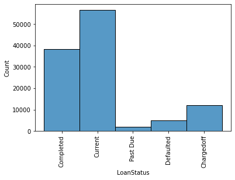

```python
sns.histplot(df['LoanStatus'])

plt.xticks(rotation=90);
```

> Naturally most loans are either completed or current

> Let's have a lock at the financial status of borrowers

```python
df['IncomeRange'].unique()
```

```
['$25,000-49,999', '$50,000-74,999', 'Not displayed', '$100,000+', '$75,000-99,999', '$1-24,999', 'Not employed', '$0']
Categories (8, object): ['Not employed' < '$0' < '$1-24,999' < '$25,000-49,999' < '$50,000-74,999' < '$75,000-99,999' < '$100,000+' < 'Not displayed']
```

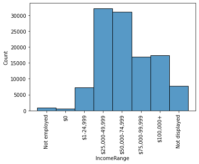

```python
incomes=['$100,000+', '$75,000-99,999',  '$50,000-74,999',
      '$25,000-49,999','$1-24,999', '$0', 'Not employed', 'Not displayed']

for inc in incomes:
    sns.histplot(df[df.IncomeRange==inc],x='IncomeRange');
plt.xticks(rotation=90);
plt.show()
```

> People with the lowest of income are very unlikey to issue loans while people with medium incomes are the most likely to borrow money

One of our objectives would be to study what affects APR, but first we have to have a look at its distrubution.

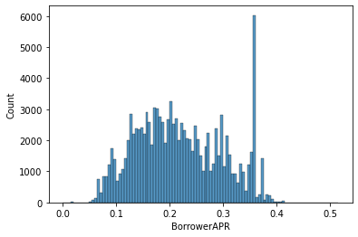

```python
binsize = 0.005
bins = np.arange(0, df['BorrowerAPR'].max()+binsize, binsize)

sns.histplot(df, x='BorrowerAPR', bins=bins);
```

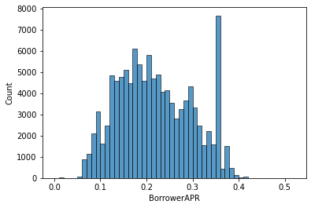

```python
binsize = 0.01
bins = np.arange(0, df['BorrowerAPR'].max()+binsize, binsize)
sns.histplot(df, x='BorrowerAPR', bins=bins);
```

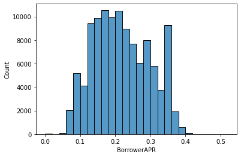

```python
binsize = 0.02
bins = np.arange(0, df['BorrowerAPR'].max()+binsize, binsize)
sns.histplot(df, x='BorrowerAPR', bins=bins);
```

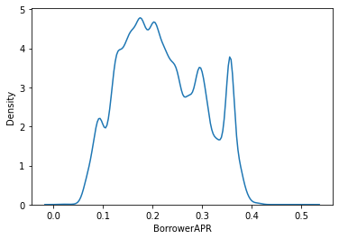

```python
sns.kdeplot(data=df, x='BorrowerAPR')
```

```python
df.columns
```

```
Index(['CreditScoreRangeLower', 'CreditScoreRangeUpper', 'Term', 'LoanStatus',
       'BorrowerAPR', 'BorrowerRate', 'IncomeRange', 'Recommendations',
       'Investors', 'LoanOriginalAmount', 'completed'],
      dtype='object')
```

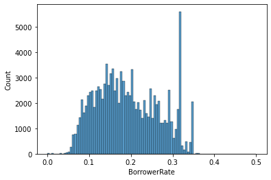

```python
binsize = 0.005
bins = np.arange(0, df['BorrowerRate'].max()+binsize, binsize)
sns.histplot(df, x='BorrowerRate', bins=bins);
```

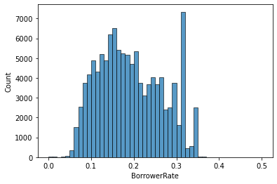

```python
binsize = 0.01
bins = np.arange(0, df['BorrowerRate'].max()+binsize, binsize)
sns.histplot(df, x='BorrowerRate', bins=bins);
```

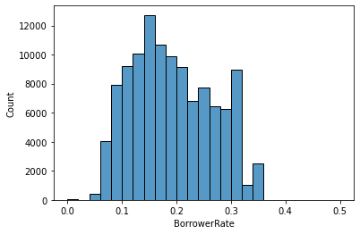

```python
binsize = 0.02
bins = np.arange(0, df['BorrowerRate'].max()+binsize, binsize)
sns.histplot(df, x='BorrowerRate', bins=bins);
```

The Borrower rates and APR look suspiciously similar...let us make sure

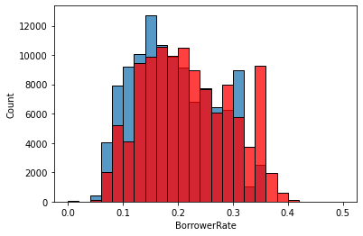

```python
binsize = 0.02
bins = np.arange(0, df['BorrowerRate'].max()+binsize, binsize)
sns.histplot(df, x='BorrowerRate', bins=bins);
sns.histplot(df, x='BorrowerAPR', bins=bins, color='r');
```

Well, No they are likely to be correlated but apparently not identical

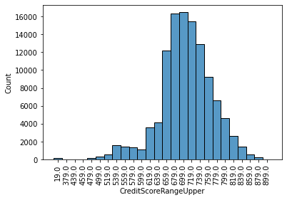

```python
scores=np.sort(df['CreditScoreRangeUpper'].unique())
scores=scores[~np.isnan(scores)].astype(str)
for score in scores:
    sns.histplot(df[df.CreditScoreRangeUpper.astype(str)==score].astype(str),x='CreditScoreRangeUpper');
plt.xticks(rotation=90);
plt.show()
```

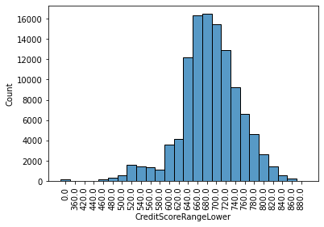

```python
scores=np.sort(df['CreditScoreRangeLower'].unique())
scores=scores[~np.isnan(scores)].astype(str)
for score in scores:
    sns.histplot(df[df.CreditScoreRangeLower.astype(str)==score].astype(str),x='CreditScoreRangeLower');
plt.xticks(rotation=90);
plt.show()
```

> Again, The last 2 features look suspiciously identical...Are the features (CreditScoreRangeLower, CreditScoreRangeUpper) redundant??? Let's find out

```
19.0
```

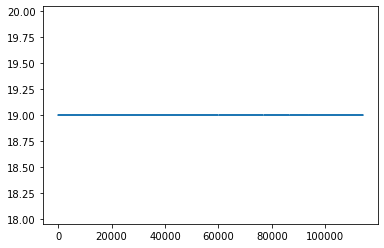

```python
print((df['CreditScoreRangeUpper']-df['CreditScoreRangeLower']).mean())
plt.plot(df['CreditScoreRangeUpper']-df['CreditScoreRangeLower']);
```

> Redundant features they are....Upper score is simply the lower score offsetted by 19. Let's remove one of them,

```python
df.drop('CreditScoreRangeLower', axis=1, inplace=True)
```

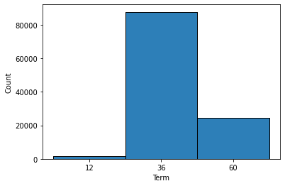

```python
scores=np.sort(df['Term'].unique())
scores=scores[~np.isnan(scores)].astype(str)
for score in scores:
    sns.histplot(df[df.Term.astype(str)==score].astype(str),x='Term');
sns.histplot(df['Term'].astype(str));
```

> The dominant majority of borrowers go for a 36 month loan period.

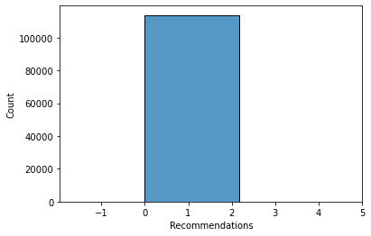

```python
rec=np.sort(df['Recommendations'].unique())
rec=rec[~np.isnan(rec)].astype(str)
for r in rec:
    sns.histplot(df[df.Recommendations==r],x='Recommendations');
sns.histplot(df['Recommendations']);
plt.xlim(right=5);
```

```python
df.Recommendations.value_counts()
```

```
0     109673
1       3516
2        568
3        108
4         26
5         14
9          6
7          5
6          4
8          3
16         2
18         2
24         1
14         1
19         1
21         1
39         1
Name: Recommendations, dtype: int64
```

Almost everybody has no recommendations. Those who do have are expected to have advantages which we can investigate in our bivariate analysis

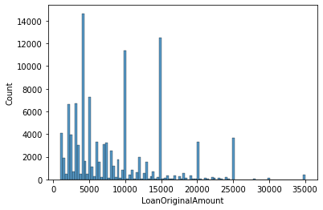

```python
sns.histplot(df['LoanOriginalAmount']);
```

Those spikes look very interesting...let's narrow the bins and see what happens

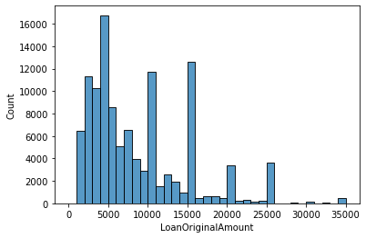

```python
binsize = 1000
bins = np.arange(0, df['LoanOriginalAmount'].max()+binsize, binsize)
sns.histplot(df, x='LoanOriginalAmount', bins=bins);
```

Interesting... the spikes are still visible even if they are lower

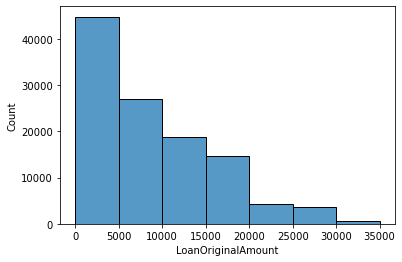

```python
binsize = 5000
bins = np.arange(0, df['LoanOriginalAmount'].max()+binsize, binsize)
sns.histplot(df, x='LoanOriginalAmount', bins=bins);
```

Finally we reached the point of no interesting information....lower ranges (5000) of loans are more common...no kidding!!!

Interestingly within every wide range of (5000) there are more popular ranges (Spikes) that were visible in the first 2 plots. It apparently is the case that within each "financial class" the macro pattern observed in the last plot is somewhat repeated.

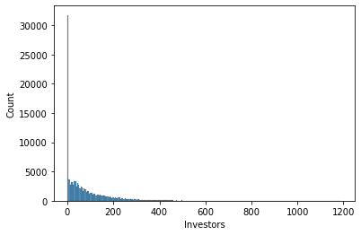

```python
#binsize = 5000
#bins = np.arange(0, df['LoanOriginalAmount'].max()+binsize, binsize)
sns.histplot(df, x='Investors');
#plt.xlim(right=5)
plt.show()
```

Okay a distribution is hardly visible....let's zoom in

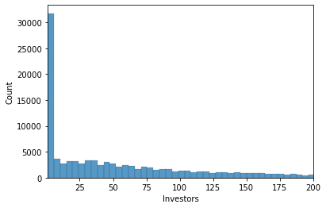

```python
sns.histplot(df, x='Investors');
plt.xlim(right=200)
plt.xlim(left=1)
plt.show()
```

Well, unsurprisingly most borrowers do not have that many investors. However, being a financial noob myself, I find it surprising that the number of investors go down....relatively slowly

# Bivariate Exploration

> Let us investigate the factors impacting APR and loan completion

## 1- Loan Completion

```python
df.columns
```

```
Index(['CreditScoreRangeUpper', 'Term', 'LoanStatus', 'BorrowerAPR',
       'BorrowerRate', 'IncomeRange', 'Recommendations', 'Investors',
       'LoanOriginalAmount', 'completed'],
      dtype='object')
```

```python
df.LoanStatus.unique()
```

```
array(['Completed', 'Current', 'Past Due', 'Defaulted', 'Chargedoff'],
      dtype=object)
```

**Let's see if there's any correlation between credit score and the Completion of a Loan**

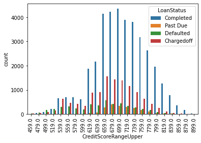

```python
sns.countplot(data = df.loc[(df.CreditScoreRangeUpper>=459) & (df.LoanStatus != 'Current')], x = 'CreditScoreRangeUpper', hue = 'LoanStatus')
plt.xticks(rotation=90);
```

> Not Very helpful, is it?  
> Let's try plotting relative frequencies instead  
> First we need to calculate and store them

```python
# Will need this throughout
def relative_freq_loanstat(col, sort=True):

    loan_status=df.LoanStatus.unique()
    loan_status=loan_status[loan_status != 'Current'] # We are not currrently interesrted in current loans

    unique_values=df[col].unique()
    unique_values=unique_values[~np.isnan(unique_values)]
    if sort:
        unique_values=np.sort(unique_values)
    status_df = pd.DataFrame(index=unique_values, columns=loan_status)

    for value in unique_values:
        for stat in loan_status:
            total_count=df.loc[(df[col] == value) & (df.LoanStatus != 'Current')].shape[0]
            if total_count>0:
                rel_freq= df.loc[(df[col] == value)&(df.LoanStatus == stat)].shape[0]/ total_count
            else:
                rel_freq=0
            status_df.loc[value, stat] = rel_freq
    return status_df
```

```python
status_score=relative_freq_loanstat('CreditScoreRangeUpper')
```

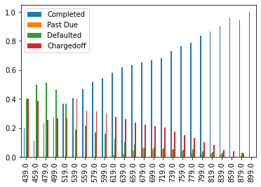

```python
status_score[status_score.index>400].plot(kind='bar');
```

> Very SMOOTH.  
> As expected the relative frequency of charged off and defaulted goes down as the credit score increases while the percentage of completed loans goes up  
> However, we cannot see any information about 'Past Due' Loans as they are apparently very rare.  
> Let's have a closer look we expect they should also decrease in frequency with the increase in credit scores.

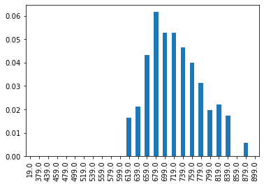

```python
status_score['Past Due'].plot(kind='bar');
```

> Very Suspicious plot here. Quite clearly the percentage of past due loans is very low and we couldn't have inferred that much from this plot anyways. Apparently due to randomness(very small sample size) we are having this counter-intuitive plot up there where past due loans go up with the increasing of the credit score and start to go down at a credit score of 679

**Let is see if we can infer any relationship between the length of the loan and its completness**  
We would follow the same steps as before calculating relative frequencies

```python
status_terms=relative_freq_loanstat('Term')
```

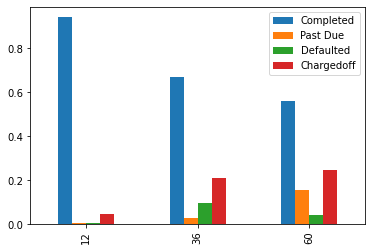

```python
status_terms.plot(kind='bar');
```

Interesting....the higher the term of the loan the less likely (and more difficult) it is to be completed

**The higher the Income the more likely the loan would be completed, right? Let's make sure**  
We would follow the same steps as before calculating relative frequencies

```python
loan_status=df.LoanStatus.unique()
status_income=pd.DataFrame(index=incomes, columns=loan_status) #incomes were defined in the univariate section
for inc in incomes:
    for stat in loan_status:
        rel_freq= df.loc[(df.IncomeRange == inc)&(df.LoanStatus == stat)].shape[0]/ df.loc[(df.IncomeRange == inc) & (df.LoanStatus != 'Current')].shape[0]
        status_income.loc[inc, stat] = rel_freq
```

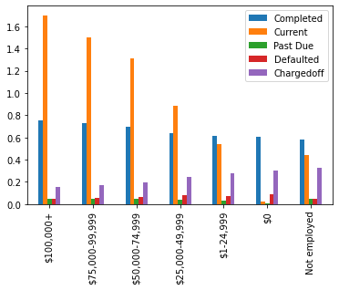

```python
ax=status_income[status_income.index != 'Not displayed'].plot(kind='bar');
ax.legend(loc='best');
```

> No surprises whatsover here.

**Is recommendations a good predictor for the completeness of a loan??**

```python
status_recom=relative_freq_loanstat('Recommendations')
```

```python
df.Recommendations.value_counts()
```

```
0     109673
1       3516
2        568
3        108
4         26
5         14
9          6
7          5
6          4
8          3
16         2
18         2
24         1
14         1
19         1
21         1
39         1
Name: Recommendations, dtype: int64
```

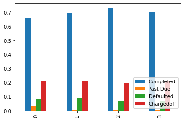

```python
ax=status_recom[status_recom.index<=3].plot(kind='bar');
#only recommendations below 3 because there are so few borrowers who has higher recommendations
ax.legend(loc='lower right')
```

For less than 3 recommendations we don't have a clear impact on the completion ratio of the loan  
For higher than 3 recommendations however we hardly have enough samples to make any conclusions

**How about the number of investors?**

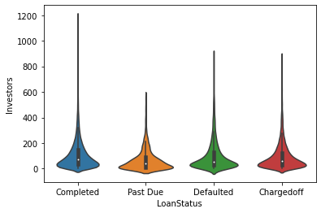

```python
sns.violinplot(data=df[df.LoanStatus!='Current'], x='LoanStatus', y='Investors')
```

No clear correlation but we can see that those who had a very high number of investors are slighly less likely to have thier loan labeled incomplete while those who have very few investors are more likely to have thier loans labeled incomplete.  
However, the impact is not obvious.

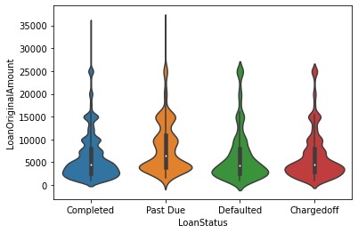

```python
sns.violinplot(data=df.loc[(df.LoanStatus!='Current')], x='LoanStatus', y='LoanOriginalAmount')
```

Interestingly, it does NOT seem that the amount of loans have an obvious impact on the completion rate.